# Lesson 4

### Scatterplots and Perceived Audience Size

Notes:

### Scatterplots

Notes:

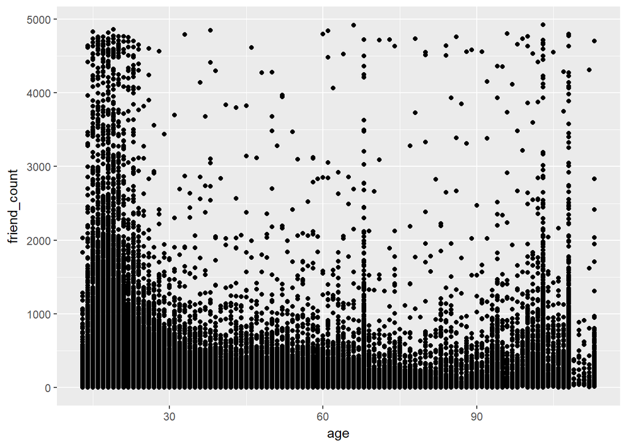

```r
library(ggplot2)
pf <- read.csv('pseudo_facebook.tsv', sep = '\t')

qplot(x=age, y=friend_count, data=pf)
```

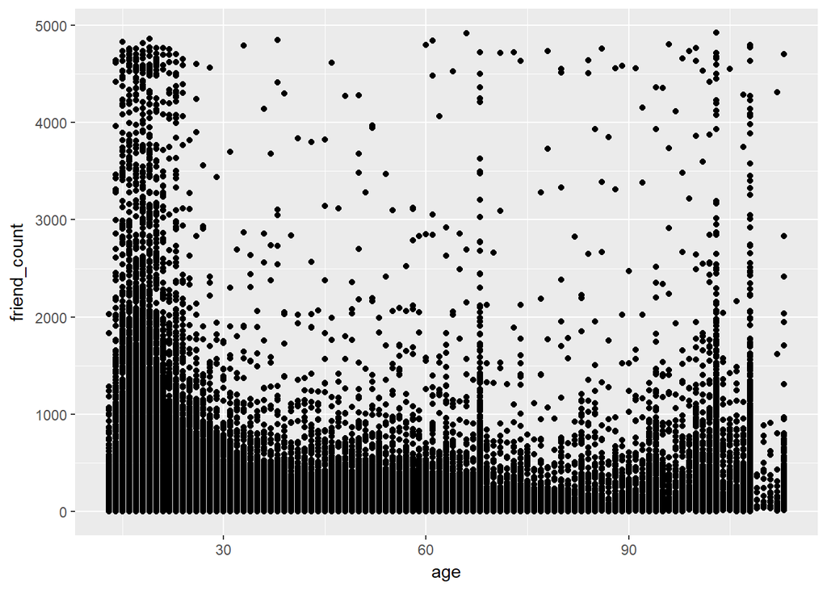

```r
qplot(age, friend_count, data=pf)
```

#### What are some things that you notice right away?

Response:

Younger users have more friends

### ggplot Syntax

Notes:

### Overplotting

Notes:

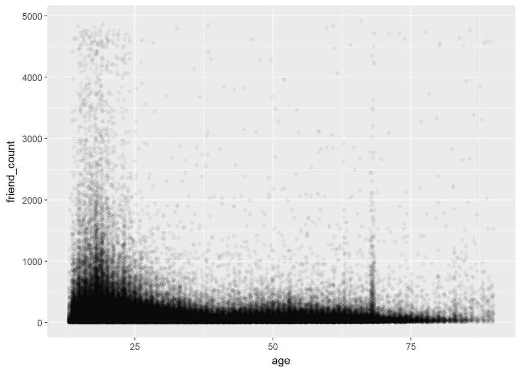

```r
ggplot(aes(x=age, y=friend_count), data=pf) +
  geom_jitter(alpha = 1/20) +
  xlim(13,90)
```

#### What do you notice in the plot?

Response:

There is a spike at the age 70 ***

### Coord_trans()

Notes:

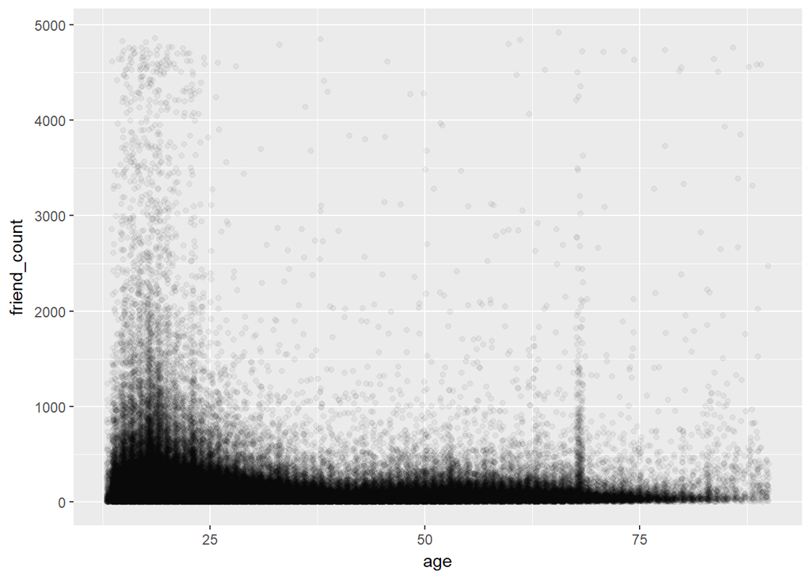

```r
ggplot(aes(x=age, y=friend_count), data=pf) +
  geom_jitter(alpha = 1/20) +
  xlim(13,90)
```

#### Look up the documentation for coord_trans() and add a layer to the plot that transforms friend_count using the square root function. Create your plot!

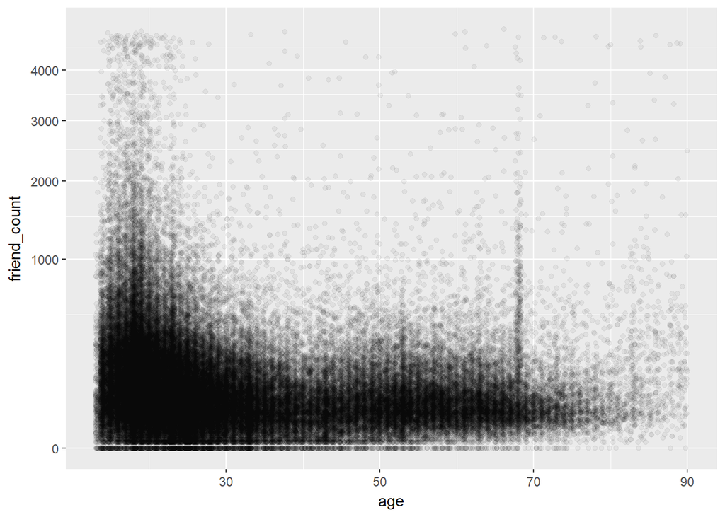

```r
ggplot(aes(x=age, y=friend_count), data=pf) +
  geom_point(alpha = 1/20, position = position_jitter(h=0)) +
  xlim(13,90) +
  coord_trans(y = 'sqrt')
```

### Alpha and Jitter

Notes:

Explore the relationship between friends initiated vs. age

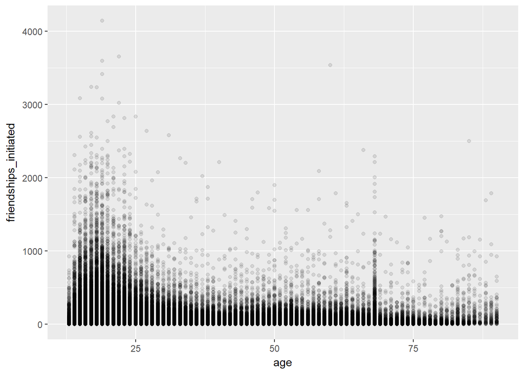

```r
ggplot(aes(x=age, y=friendships_initiated), data=pf) +
  geom_point(alpha = 1/10) +
  xlim(13,90)
```

### Overplotting and Domain Knowledge

Notes:

### Conditional Means

Notes:

Showing statistics of friend count by age

```r
#install.package('dplyr')
library(dplyr)
age_groups <- group_by(pf,age)
pf.fc_by_age <- summarise(age_groups,
          friend_count_mean = mean(friend_count),
          friend_count_median = median(friend_count),
          n = n())
head(pf.fc_by_age)
```

```
## # A tibble: 6 x 4
##     age friend_count_mean friend_count_median     n
##   <int>             <dbl>               <dbl> <int>
## 1    13          164.7500                74.0   484
## 2    14          251.3901               132.0  1925
## 3    15          347.6921               161.0  2618
## 4    16          351.9371               171.5  3086
## 5    17          350.3006               156.0  3283
## 6    18          331.1663               162.0  5196
```

Create your plot!

Create a line plot of age and friend count mean

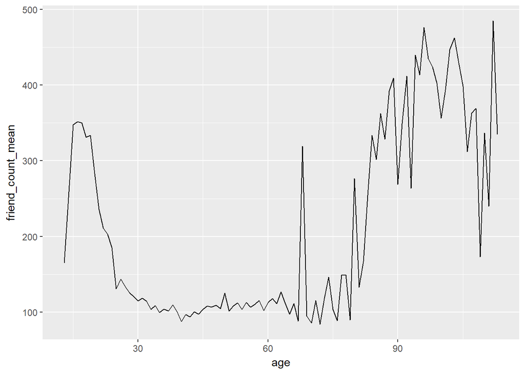

```r
ggplot(aes(x = age, y = friend_count_mean), data=pf.fc_by_age) +
  geom_line()
```

### Overlaying Summaries with Raw Data

Notes: Overlaying the mean friend line over the scatter plot of data.

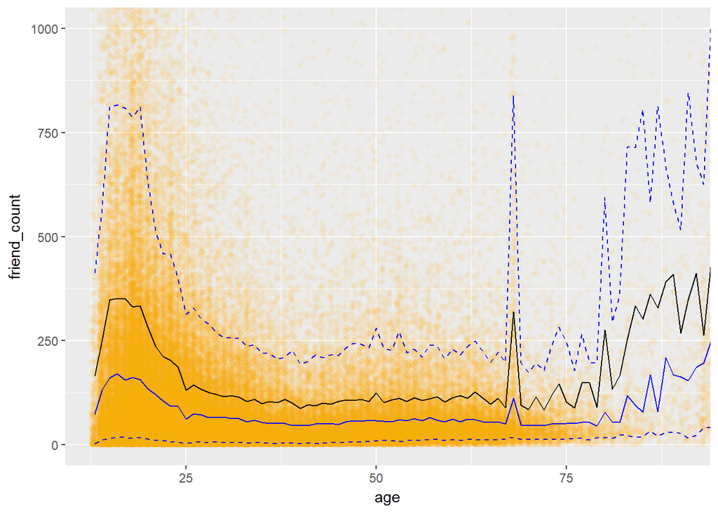

```r
ggplot(aes(x=age, y=friend_count), data=pf) +
  geom_point(alpha = .05,
             position = position_jitter(h=0),
             color='orange') +
  coord_trans(y='sqrt') +
  geom_line(stat='summary', fun.y=mean) +
  geom_line(stat='summary', fun.y=quantile, fun.args=list(probs=.1), linetype =2, color ='blue') +
    geom_line(stat='summary', fun.y=quantile, fun.args=list(probs=.9), linetype =2, color ='blue') +
      geom_line(stat='summary', fun.y=quantile, fun.args=list(probs=.5), color ='blue') +
  coord_cartesian(xlim=c(13,90), ylim=c(0,1000))
```

#### What are some of your observations of the plot?

Response:

### Moira: Histogram Summary and Scatterplot

See the Instructor Notes of this video to download Moira’s paper on perceived audience size and to see the final plot.

Notes:

### Correlation

Notes:

```r
cor.test(pf$age, pf$friend_count)
```

```
##
##  Pearson's product-moment correlation
##
## data:  pf$age and pf$friend_count
## t = -8.6268, df = 99001, p-value < 2.2e-16
## alternative hypothesis: true correlation is not equal to 0
## 95 percent confidence interval:
##  -0.03363072 -0.02118189
## sample estimates:
##         cor
## -0.02740737
```

Look up the documentation for the cor.test function.

What’s the correlation between age and friend count? Round to three decimal places. Response:

cor.test defaults to method=‘pearson’

```r
cor.test(pf$age, pf$friend_count, method='pearson')
```

```
##
##  Pearson's product-moment correlation
##
## data:  pf$age and pf$friend_count
## t = -8.6268, df = 99001, p-value < 2.2e-16
## alternative hypothesis: true correlation is not equal to 0
## 95 percent confidence interval:
##  -0.03363072 -0.02118189
## sample estimates:
##         cor
## -0.02740737
```

```r
with(pf, cor.test(age,friend_count, method='pearson'))
```

```
##
##  Pearson's product-moment correlation
##
## data:  age and friend_count
## t = -8.6268, df = 99001, p-value < 2.2e-16
## alternative hypothesis: true correlation is not equal to 0
## 95 percent confidence interval:
##  -0.03363072 -0.02118189
## sample estimates:
##         cor
## -0.02740737
```

### Correlation on Subsets

Notes:

Subset the users equal or less than 70 before running the correlation.

```r
with(subset(pf, age <= 70), cor.test(age,friend_count, method='pearson'))
```

```
##
##  Pearson's product-moment correlation
##
## data:  age and friend_count
## t = -52.592, df = 91029, p-value < 2.2e-16
## alternative hypothesis: true correlation is not equal to 0
## 95 percent confidence interval:
##  -0.1780220 -0.1654129
## sample estimates:
##        cor
## -0.1717245
```

### Correlation Methods

Notes:

## Create Scatterplots

Notes:

### Strong Correlations

Notes:

comparing www_likes_received by likes_received

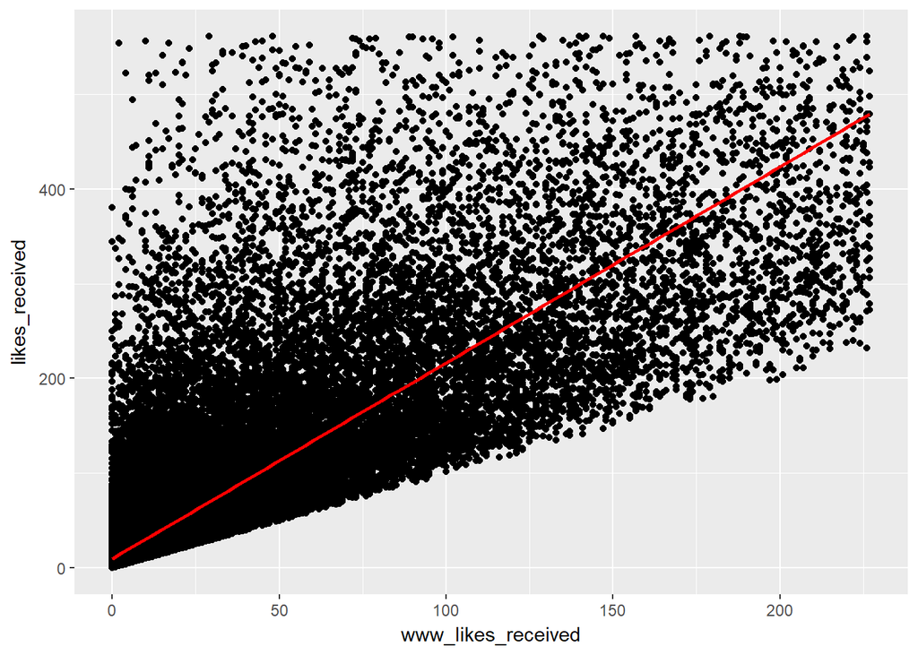

```r
ggplot(aes(x=www_likes_received, y=likes_received), data = pf) +
  geom_point() +
  xlim(0, quantile(pf$www_likes_received, 0.95)) +
  ylim(0, quantile(pf$likes_received, 0.95)) +
  geom_smooth(method='lm', color='red')
```

What’s the correlation betwen the two variables? Include the top 5% of values for the variable in the calculation and round to 3 decimal places.

```r
cor.test(pf$www_likes_received, pf$likes_received)
```

```
##
##  Pearson's product-moment correlation
##
## data:  pf$www_likes_received and pf$likes_received
## t = 937.1, df = 99001, p-value < 2.2e-16
## alternative hypothesis: true correlation is not equal to 0
## 95 percent confidence interval:
##  0.9473553 0.9486176
## sample estimates:
##       cor
## 0.9479902
```

Response:

### Moira on Correlation

Notes:

### More Caution with Correlation

Notes:

```r
#install.packages('alr3')
library(alr3)
data(Mitchell)
?Mitchell
```

```
## starting httpd help server ...
```

```
##  done
```

```r
head(Mitchell)
```

```
##   Month     Temp
## 1     0 -5.18333
## 2     1 -1.65000
## 3     2  2.49444
## 4     3 10.40000
## 5     4 14.99440
## 6     5 21.71670
```

Create your plot! # Create a scatterplot of temperature (Temp) # vs. months (Month).

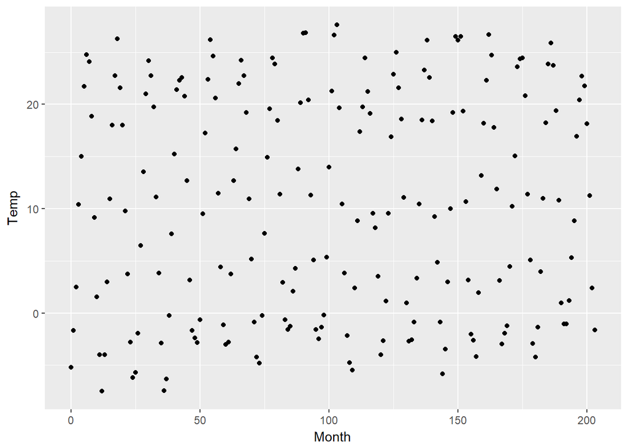

```r
ggplot(aes(x=Month, y=Temp), data = Mitchell) +
  geom_point()
```

### Noisy Scatterplots

1. Take a guess for the correlation coefficient for the scatterplot.
2. What is the actual correlation of the two variables? (Round to the thousandths place)

```r
cor.test(Mitchell$Month, Mitchell$Temp)
```

```
##
##  Pearson's product-moment correlation
##
## data:  Mitchell$Month and Mitchell$Temp
## t = 0.81816, df = 202, p-value = 0.4142
## alternative hypothesis: true correlation is not equal to 0
## 95 percent confidence interval:
##  -0.08053637  0.19331562
## sample estimates:
##        cor
## 0.05747063
```

### Making Sense of Data

Notes:

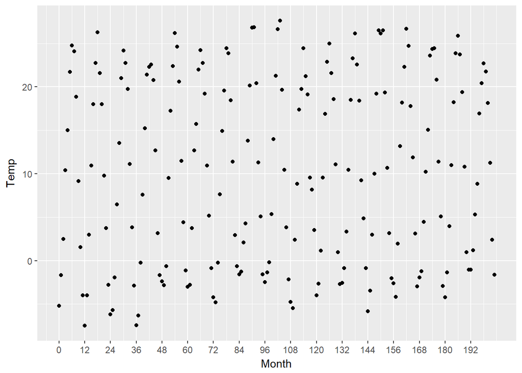

```r
ggplot(aes(x=Month, y=Temp), data = Mitchell) +
  geom_point() +
  scale_x_continuous(breaks = seq(0,203, 12))
```

### A New Perspective

What do you notice? Response:

Watch the solution video and check out the Instructor Notes! Notes:

### Understanding Noise: Age to Age Months

Notes:

```r
pf$age_with_months <- pf$age + (12 - pf$dob_month) / 12
```

### Age with Months Means

Using dplyr to group users by age_with_months, and summarize the information.

```r
library(dplyr)

pf.fc_by_age_months <- pf %>%
  group_by(age_with_months) %>%
  summarise(friend_count_mean = mean(friend_count),
            friend_count_median = median(friend_count),
            n=n()) %>%
  arrange(age_with_months)

head(pf.fc_by_age_months)
```

```
## # A tibble: 6 x 4
##   age_with_months friend_count_mean friend_count_median     n
##             <dbl>             <dbl>               <dbl> <int>
## 1        13.16667          46.33333                30.5     6
## 2        13.25000         115.07143                23.5    14
## 3        13.33333         136.20000                44.0    25
## 4        13.41667         164.24242                72.0    33
## 5        13.50000         131.17778                66.0    45
## 6        13.58333         156.81481                64.0    54
```

Programming Assignment

### Noise in Conditional Means

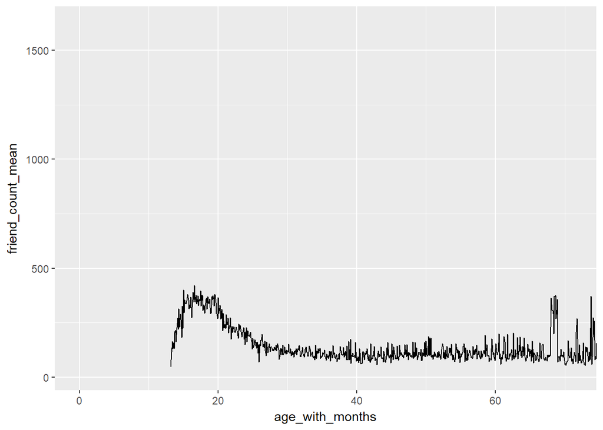

```r
ggplot(data=pf.fc_by_age_months, aes(x=age_with_months, y=friend_count_mean)) +
  geom_line() +
  coord_cartesian(xlim = c(0,71))
```

### Smoothing Conditional Means

Notes:

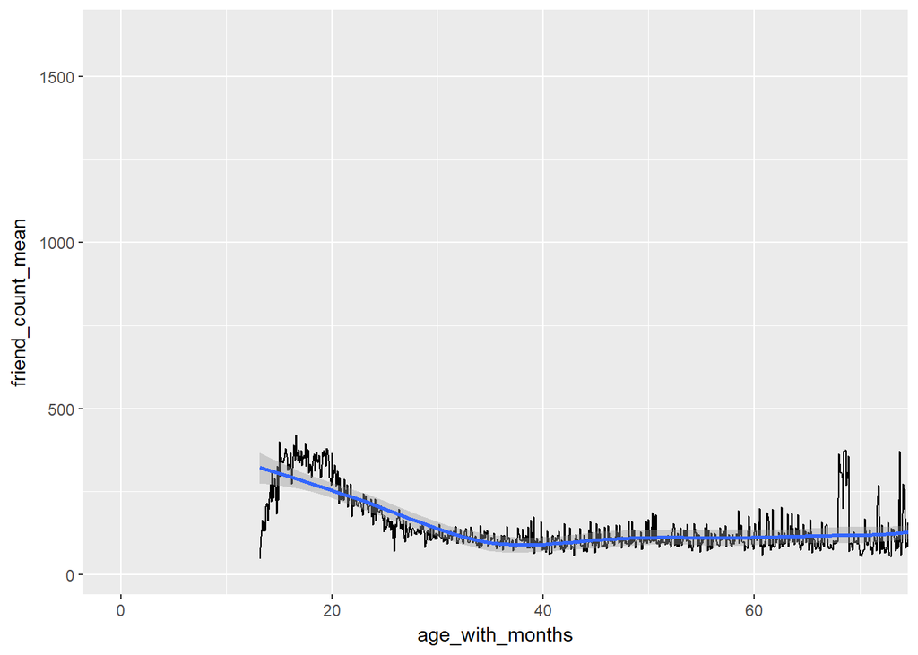

```r
ggplot(data=pf.fc_by_age_months, aes(x=age_with_months, y=friend_count_mean)) +
  geom_line() +
  coord_cartesian(xlim = c(0,71)) +
  geom_smooth()
```

### Which Plot to Choose?

Notes:

### Analyzing Two Variables

Reflection:

Click **KnitHTML** to see all of your hard work and to have an html page of this lesson, your answers, and your notes!